# Boarding Problem

This is document that solves the Riddler for the week of Feb 19, 2016 located here: http://fivethirtyeight.com/features/will-someone-be-sitting-in-your-seat-on-the-plane/

There’s an airplane with 100 seats, and there are 100 ticketed passengers each with an assigned seat. They line up to board in some random order. However, the first person to board is the worst person alive, and just sits in a random seat, without even looking at his boarding pass. Each subsequent passenger sits in his or her own assigned seat if it’s empty, but sits in a random open seat if the assigned seat is occupied. What is the probability that you, the hundredth passenger to board, finds your seat unoccupied?

For my solution, I’m assuming that the passengers are assigned seats 1 through the 100. This allows me to leverage sequential number functions. This assumption should not impact the probability.

First, I created a function called seatProb that does all for the work to determine which seats are available, which seats are taken, and where everyone sits.

```r
# nthSeat is a vector of passengers that will sit in a random seat
seatProb <- function(numSeats, passengerPosition, nthSeat, numSims) {
  answer <- NULL

  # repeat the simulation n times
  for (i in 1:numSims) {
    set.seed(i)

    seats.taken = NULL
    seats.avail <- c(1:numSeats)

    for (j in 1:numSeats) {
      #    Attempt to seat the second person through the last person in their assigned seat
      #    Each passenger will look for the seat that matches their passenger number
      if (j %in% nthSeat) seat <- sample(seats.avail, 1)           # the nth passenger will sit in random seat
      else if (j %in% seats.taken) seat <- sample(seats.avail, 1)  # seat taken
      else seat <- j                                               # seat not taken

      seats.taken[j] <- seat
      seats.avail <- seats.avail[!seats.avail == seat]
    }
    # Is the passenger in passengerPosition in their assigned seat
    # Populate the answer in answer[n]
    answer[i] <- seats.taken[passengerPosition] == passengerPosition
  }
  probability <- sum(answer + 0) / numSims
}
```

The main problem asks what is the probability of the 100th passenger sitting in their seat given that the first passenger sits in a random seat. In short, the answer is 50%.

As can be seen by the graph below, the probability of the first 90 or so passengers getting to their assigned seats is no less than 90%. As you would expect, the second passenger is almost guaranteed to reach his assigned seat. However, for those last ten folks boarding the plan, the probabilities drop quickly, with the last passenger realizing a 50% probability. See the graph below.

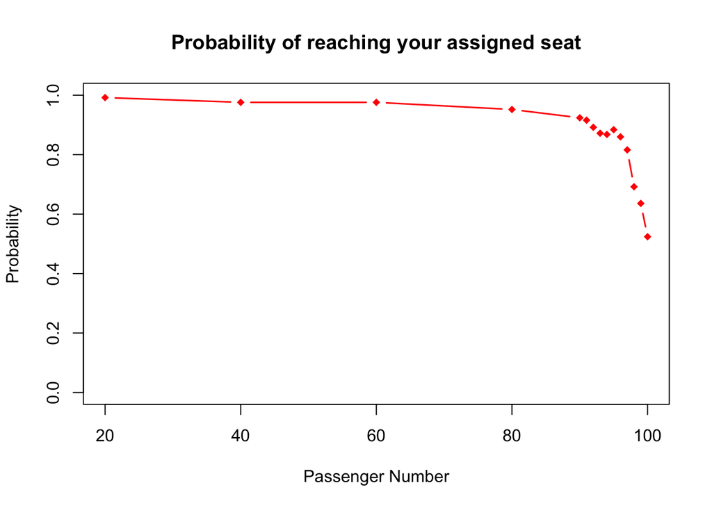

```r
position <- c(20, 40, 60, 80, 90, 91, 92, 93, 94, 95, 96, 97, 98, 99, 100)
N <- 1  # Number of different passenger configs
nSims <- 250
nSeats <- 100

seatStats <- list()
for (i in 1:N) {
  seatStats[[i]] <- sapply(position, seatProb, numSeats=nSeats, nthSeat=c(1:i), numSims=nSims)
}
firstNRandom = do.call(cbind, seatStats)

plot(position, firstNRandom[,1], type="n", xlab="Passenger Number", ylab="Probability", ylim=0:1 )
colors <- rainbow(10)
linetype <- c(1:10)
plotchar <- seq(18,28,1)

for (i in 1:N) {
  lines(position, firstNRandom[,i], type="b", lwd=1.5, lty=linetype[i], col=colors[i], pch=plotchar[i])
}
title("Probability of reaching your assigned seat")
```

During my evaluation, I also noted that if more than one passenger decided to select a random seat instead of their assigned seat, then the probabilities started to drop quickly. For example, I ran a simulation of the first two passengers selecting random seats, the first three passengers, and so on, all the way to the first ten passengers selecting random seats. In the scenario where the first ten passengers selecting random seats, the 100th passenger then only has an 11% change of getting to their assigned seat. See the graph below. for all ten simulations.

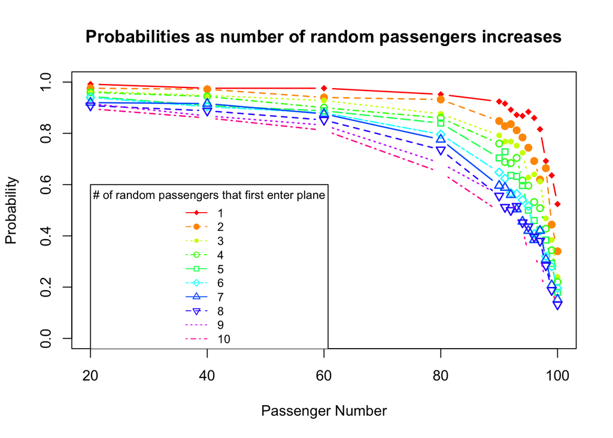

```r
position <- c(20, 40, 60, 80, 90, 91, 92, 93, 94, 95, 96, 97, 98, 99, 100)
N <- 10  # Number of different passenger configs
nSims <- 250
nSeats <- 100

seatStats <- list()
for (i in 1:N) {
  seatStats[[i]] <- sapply(position, seatProb, numSeats=nSeats, nthSeat=c(1:i), numSims=nSims)
}
firstNRandom = do.call(cbind, seatStats)

plot(position, firstNRandom[,1], type="n", xlab="Passenger Number", ylab="Probability", ylim=0:1 )
colors <- rainbow(10)
linetype <- c(1:10)
plotchar <- seq(18,28,1)

for (i in 1:N) {
  lines(position, firstNRandom[,i], type="b", lwd=1.5, lty=linetype[i], col=colors[i], pch=plotchar[i])
}
title("Probabilities as number of random passengers increases")

legend(x=20, y=0.6, 1:N, cex=0.8, col=colors, pch=plotchar,
       lty=linetype, title="# of random passengers that first enter plane")
```